# Who are ASM Journals? A Gender Analysis

## Both men and women reviewers more frequently suggest rejection for papers authored by women

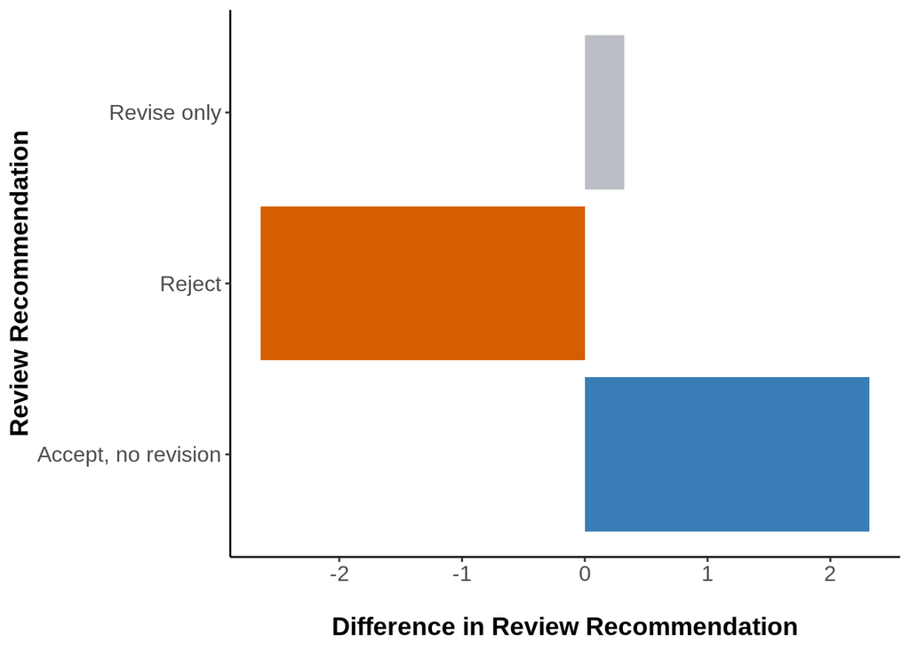

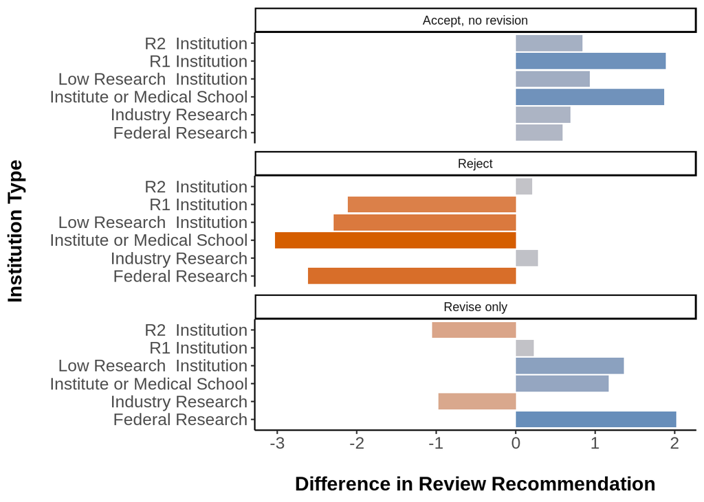

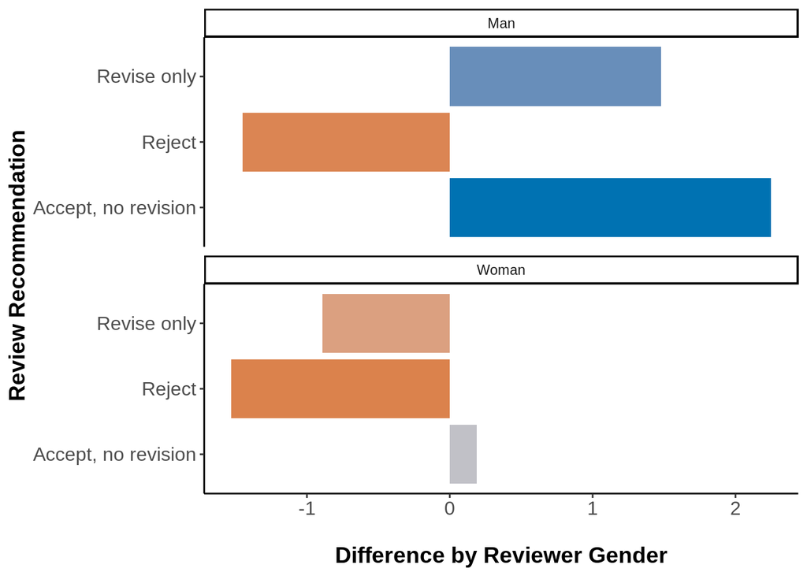

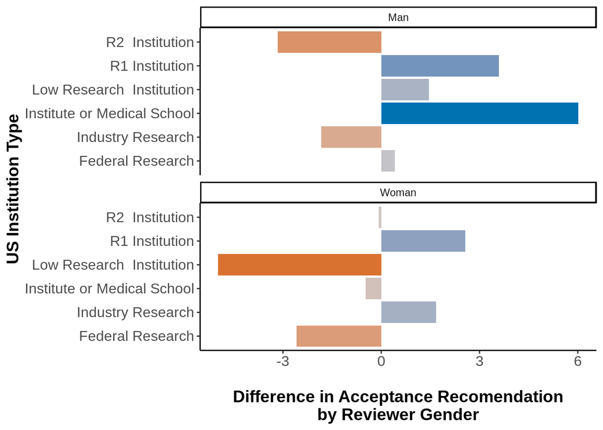

- rev_score_analysis.R
  - reviewers are more likely to suggest rejections for women as compared to men. No difference in revise decisions (A)
  - men at R1, low research, medical schools & fed research are favored by reviewers over women (B)
- reviewer_gender_analysis.R
  - both female & male reviewers are more likely to recommend rejection for women. (C)
  - Male reviewers are more likely to accept papers from men (C)
  - women reviewers are more likely to recommend acceptance for women from low research & federal institutions (D)
  - women reviewers are more likely to recommend acceptance for men from R1 & industry instutitions (C)
  - men are more likely to recommend acceptance for women from R2 institutions & favor men from R1 & medical institutes (D)

## Factors affecting competency

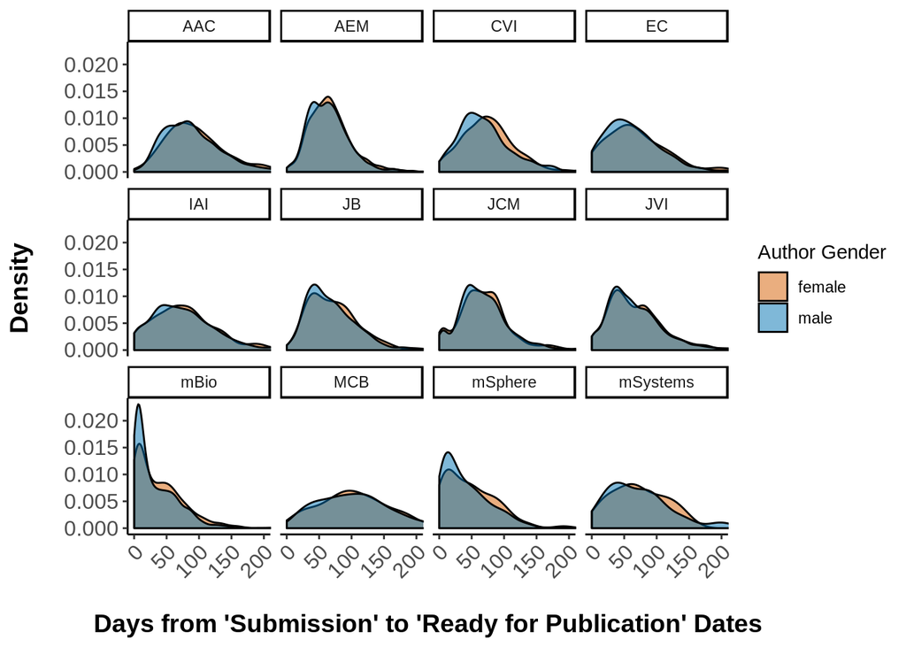

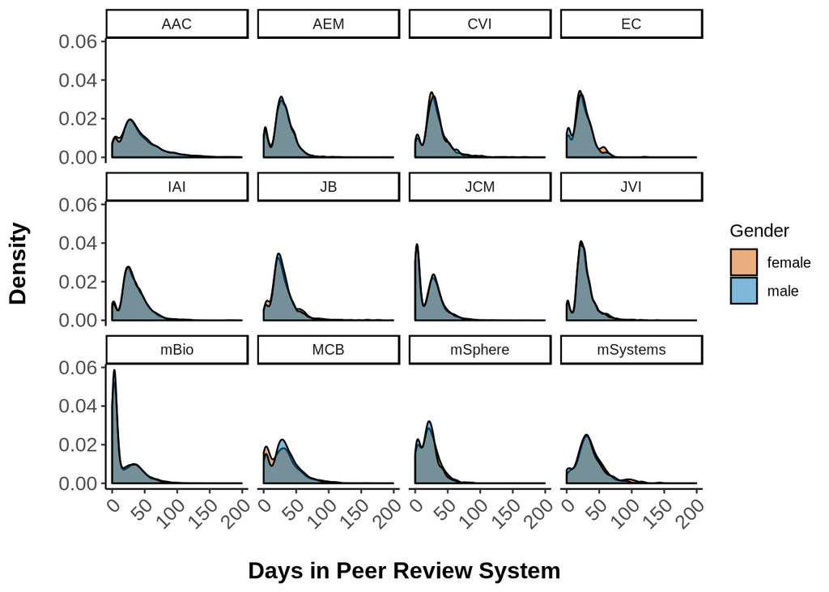

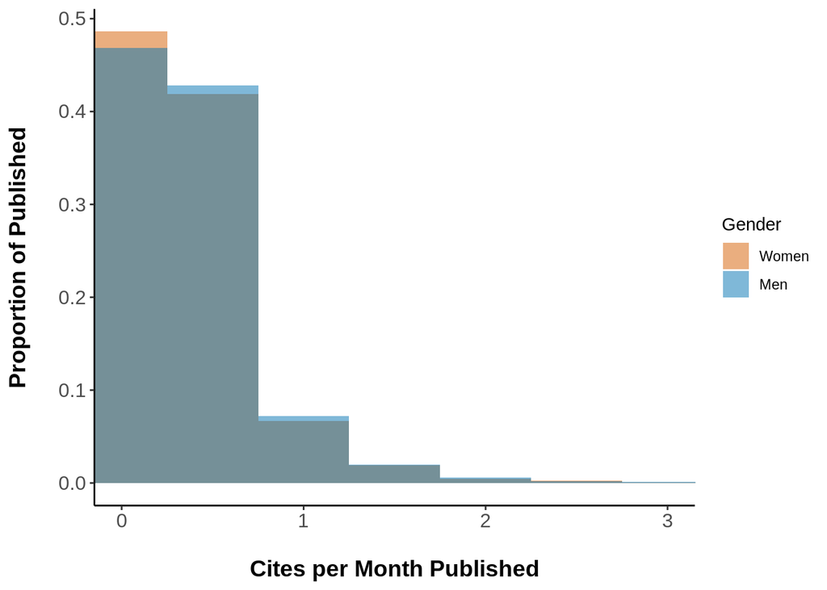

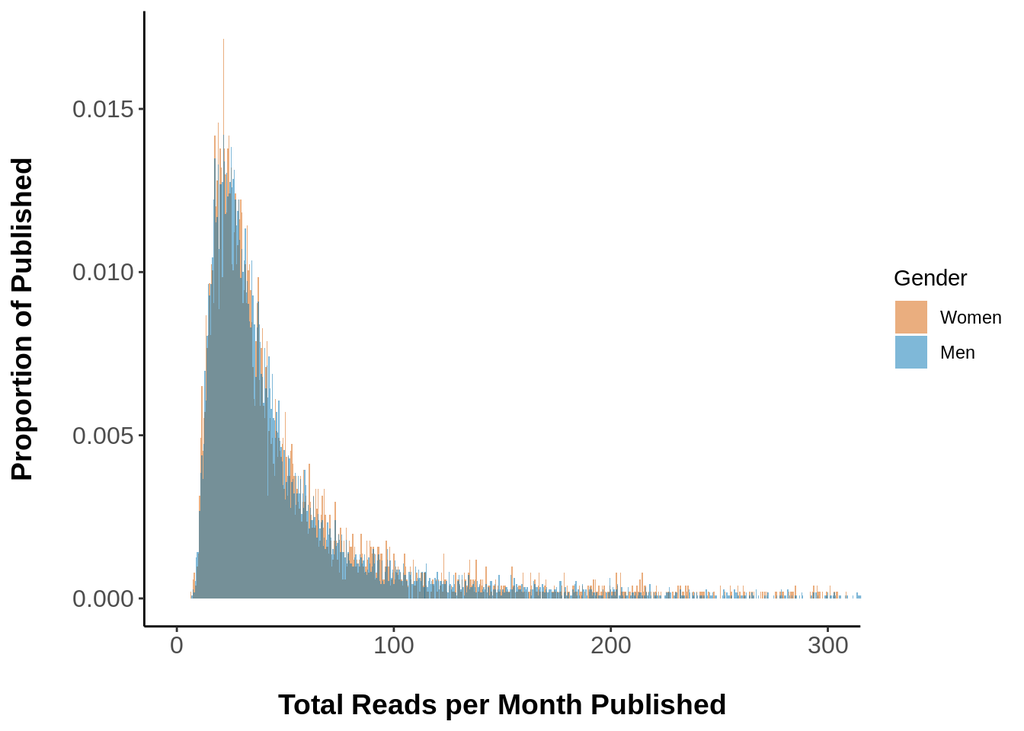

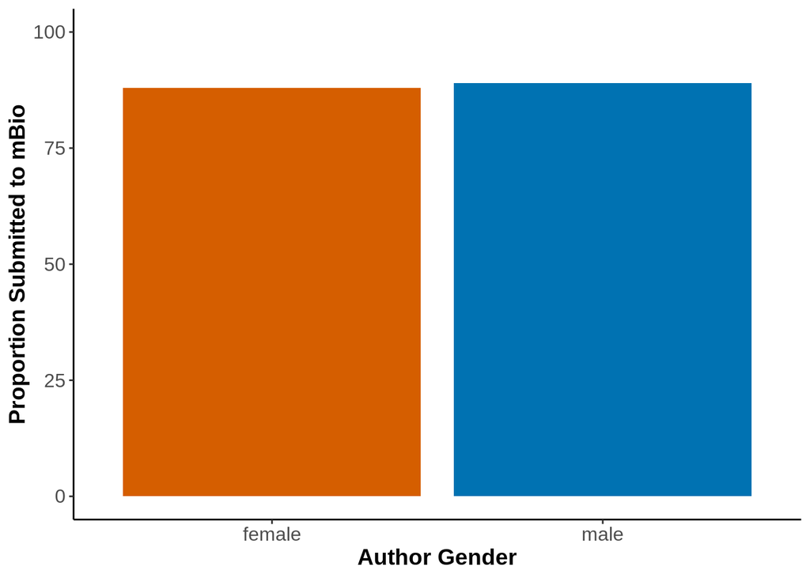

- In addition to rejectance/acceptance rates, other disparate outcomes may occur during the peer review process
- Time in Peer Reivew (time_to_publication.R)
  - Papers published by women take slightly longer (from submission to ready for publication) than men at some journals (mSphere, mBio, mSystems, CVI, JB, JCM, AEM) despite spending similar amounts of time at ASM journals (A, B)
  - but do not require a greater number of revisions to be accepted than men (Supplementary_C)
  - Papers rejected following review that were submitted by women do not generally take longer (in days) to be rejected (except at mSystems) or have more revisions (Supplementary_D & _E)
  - Decisions are returned to men & women similarly (time_at_journ.R)
- Peer review is not a linear process, it is cyclical and builds upon its self, may also be disparities in impact (impact_analysis.R)
  - Women tend to receive lower cites per month published than men
  - HTML/PDF/Abstract views are equivalent
  - women are more likely to be published in lower JIF journals
  - No disparity in gendered sumissions to high (mBio) vs lower (mSphere) journals (bias_by_jif.R)